# Fast-tracking solutions to the coronavirus pandemic

19.04.2022

**Coronavirus-related research funded by the SNSF is successfully delivering fast and beneficial results.**

The coronavirus pandemic that we have been living with since early 2020 has highlighted the importance of scientific research. Since it was completely unknown until it struck, the virus had to be decoded quickly so that scientists could develop effective medicines and vaccines and establish what preventive measures needed to be taken. The SNSF contributed to these efforts by funding various research projects. Here is an overview.

### Understanding the virus

The SNSF funded or is still funding 107 coronavirus-related projects, to which it awarded a total of 45 million francs.

The sheer variety of the projects is best illustrated by a word cloud. This provides a visual representation of how often specific keywords have been used in the various coronavirus projects. It shows clearly that scientists’ number one priority is to gain a better understanding of the virus and the associated health risks.

Word cloud on Covid-19 projects

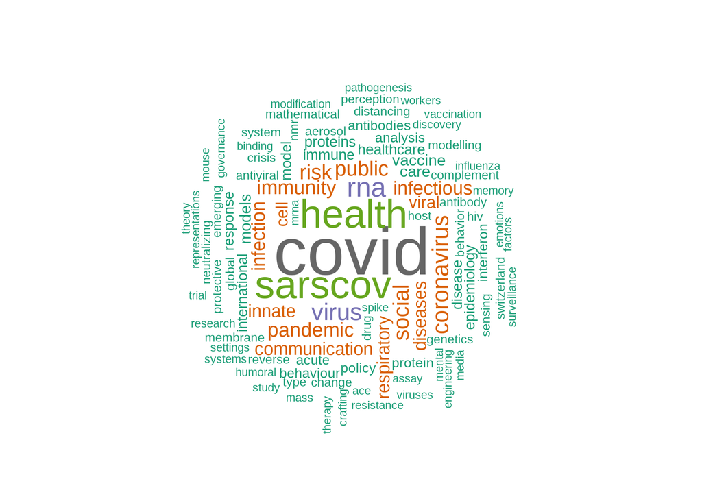

### Different funding formats

The projects have been funded under various schemes: a special call for coronavirus projects resulted in 45 projects being financed from summer 2020, while the [National Research Programme «Covid-19» (NRP 78)](https://www.nfp78.ch/en/) mandated by the Federal Council has provided funding for 28 projects. The SNSF’s flagship project funding scheme also attracted proposals associated to a greater or lesser extent with coronavirus – both before the pandemic and since its onset. The number of projects in question is 34 and encompass a total 184 applicants.

Number and percentage of Covid-related grant projects (total of 107) within each call group

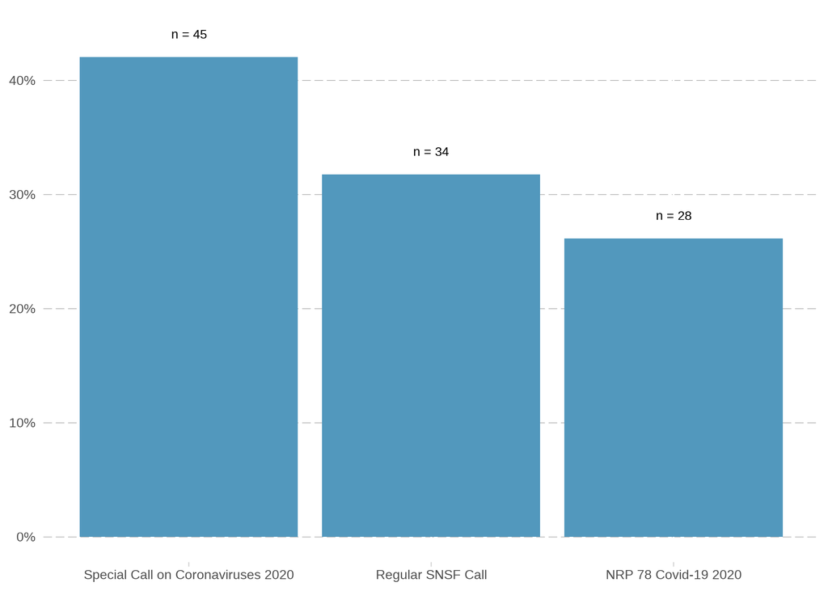

### Beneficial results

Coronavirus-related projects last an average of two years. Some have already delivered their results and produced publications that have helped drive forward the pandemic response. There have been 87 publications in the life sciences and 32 in the social sciences and humanities. These numbers are set to rise, given that 69% of projects are still ongoing.

Here are two examples:

- In their publication, the team led by Volker Thiel, a virologist at the University of Bern and the Institute of Virology and Immunology IVI, highlight the potential of their nasally administered live attenuated vaccine. Its development is ongoing and entering the clinical trial phase.
- An [article](https://www.manchesteropenhive.com/view/journals/hrv/7/2/article-p41.xml) co-authored by researcher Marc-Antoine Berthod looks at the changes that the pandemic has brought about in funeral practices.

The SNSF has also communicated a number of results, notably:

- A [statistical model](https://www.snf.ch/en/BZARkjTMtrt48Gcb/news/the-impact-of-border-and-school-closures-to-control-coronavirus) for measuring the impact of border and school closures
- The development of a [non-contagious model of SARS-CoV-2](https://www.snf.ch/en/IR4xqilNfvUoe4E7/news/model-of-sars-cov-2-improves-drug-research-and-development) to improve research and drug development
- A [cohort study](https://www.snf.ch/en/6AywkKU0LqBlQ92j/news/more-insight-into-long-covid) of 3,000 people, which revealed a correlation between the severity of infection and the onset of long Covid symptoms
- A method for quickly and cost-efficiently estimating the [reproduction rate](https://www.snf.ch/en/Mhz1a3piOEoSgb2B/news/wastewater-provides-new-insight-into-covid-19-dynamics) of coronavirus using wastewater
- New [Swiss vaccine candidates](https://www.nfp78.ch/en/news/swiss-vaccine-candidates-enter-clinical-trial-phase/) developed as part of NRP 78 ([see also](https://www.snf.ch/en/XZ6J2kZHkf5aMROA/news/innovative-research-into-new-vaccines))

### Life sciences top the rankings

A more detailed analysis of the projects being funded shows that nearly two thirds of them are in the life sciences, nearly one third in the social sciences and humanities and just a small number in mathematics, natural and engineering sciences. This distribution reflects the nature of the challenge presented by the pandemic and contrasts with SNSF-funded projects as a whole, where there is a more even spread.

Number and percentage of Covid-related grant projects (total of 107) per research area

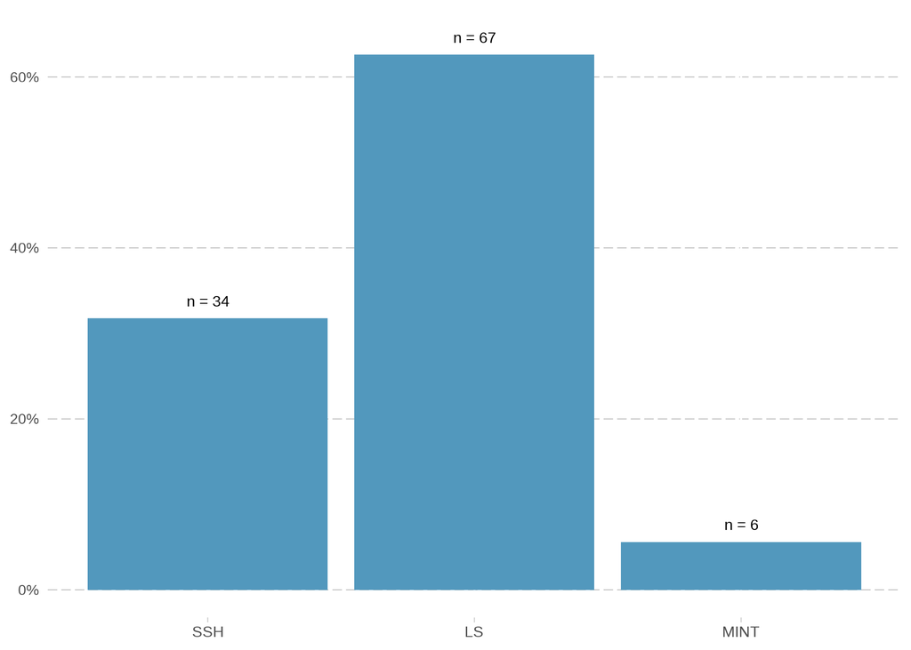

Total amount of money awarded (in Swiss francs) on 107 Covid-related grant projects for each research area

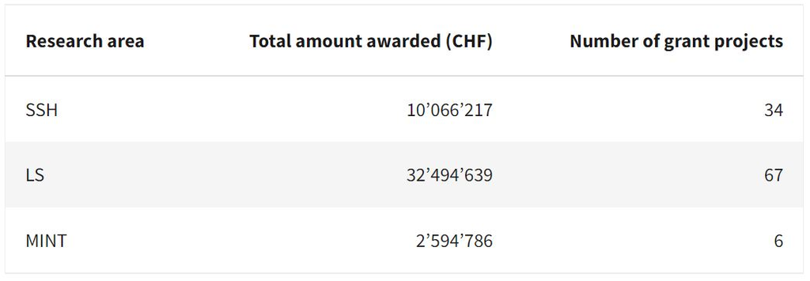

| Research area | Total amount awarded (CHF) | Number of grant projects |
| --- | --- | --- |
| SSH | 10’066’217 | 34 |
| LS | 32’494’639 | 67 |
| MINT | 2’594’786 | 6 |

The chart below shows the number and percentage of coronavirus-related projects in each discipline. Once again, it is clear that certain disciplines predominate. It comes as no surprise that preventive medicine tops the list. It is followed by basic biological research, where most of the projects are aimed at better understanding the virus. On the other hand, some humanities and social science projects are investigating society’s responses to the pandemic and its consequences.

Number and percentage of Covid-19-related grant projects (total of 107) per research discipline

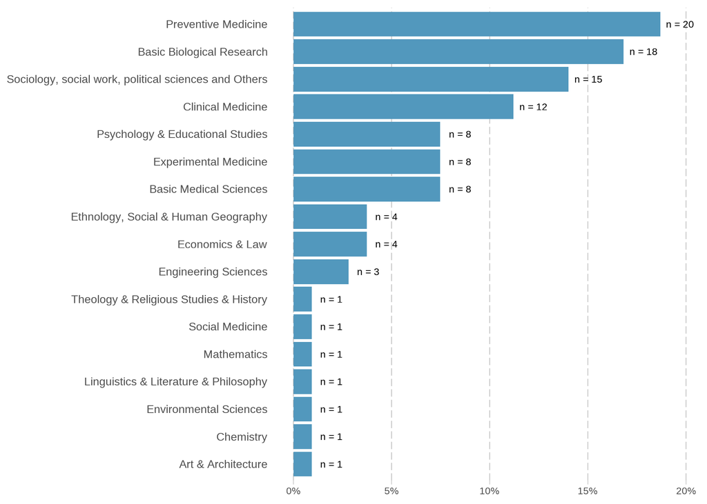

### Basic research requires significant funding

Basic research is time-consuming and laborious; the table shows that the discipline that received most money – namely 10.7 million francs – is basic biological research.

Total amount awarded (in Swiss francs) for Covid-related grant projects in the seven most represented disciplines

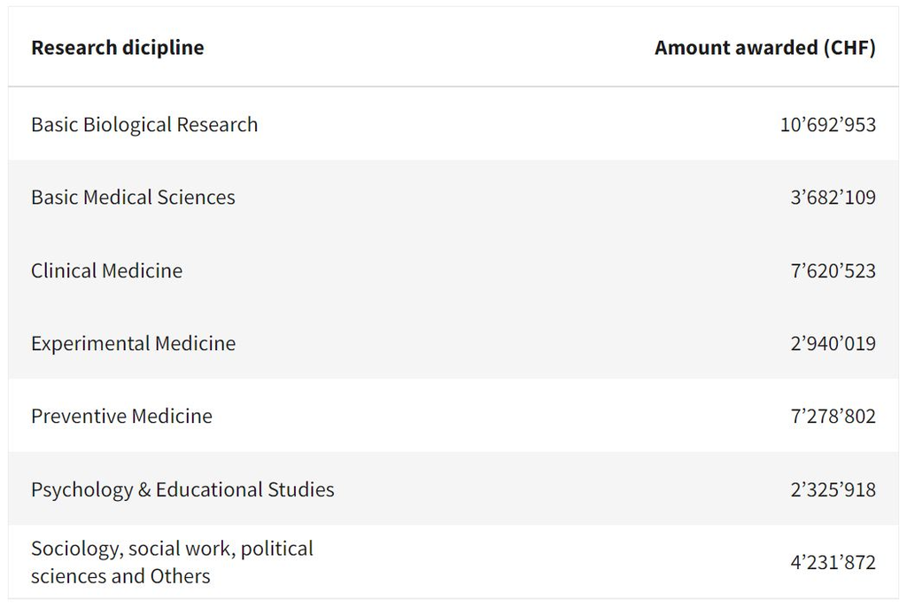

| Research dicipline | Amount awarded (CHF) |
| --- | --- |
| Basic Biological Research | 10’692’953 |
| Basic Medical Sciences | 3’682’109 |
| Clinical Medicine | 7’620’523 |
| Experimental Medicine | 2’940’019 |
| Preventive Medicine | 7’278’802 |
| Psychology & Educational Studies | 2’325’918 |
| Sociology, social work, political sciences and Others | 4’231’872 |

### Covid-19 project registry

All coronavirus-related research projects have been collected in the [Covid-19 research project registry](https://data.snf.ch/covid-19). This project registry provides an overview of Swiss Covid-19 research funded by the SNSF, Innosuisse and the European research and innovation funding programme Horizon 2020.

The data, text and code associated with this data story are available on [Github](https://github.com/snsf-data/datastory_covid_19_funding) and archived on [Zenodo](https://doi.org/10.46446/datastory.covid-19-funding). DOI: 10.46446/datastory.covid-19-funding